# Parent reformulations corpus analysis

```r
library(tidyverse)
library(childesr)
library(wordbankr)
library(here)
library(glue)
library(lme4)
library(tidyboot)
library(ggthemes)
library(broom)
library(broom.mixed)
```

# Sampling from Corpus

### Defining a set of irregular plurals to search for in CHILDES Database

```r
correct_plurals <- tibble(word = c("mouse", "snowman", "man", "woman", "child",
                                   "foot","tooth","goose", "leaf", "wolf",
                                    "wife", "knife", "half", "policeman", "mailman",
                                   "newsman", "postman", "fireman", "fisherman"),
                          plural = c("mice", "snowmen", "men","women","children",
                                     "feet","teeth","geese", "leaves", "wolves",
                                     "wives", "knives", "halves", "policemen",
                                     "mailmen", "newsmen", "postmen", "firemen",
                                     "fishermen")) %>%
  mutate(plural_type = "correct")

overregularized_plurals <- tibble(word = c("mouse", "mouse",
                                           "snowman", "snowman",
                                           "man", "man",
                                           "woman", "woman",
                                           "child", "child",
                                           "foot", "foot",
                                           "tooth", "tooth",
                                           "goose", "goose",
                                           "leaf",
                                           "wolf",
                                           "wife",
                                           "knife",
                                           "half",
                                           "policeman", "policeman",
                                           "mailman", "mailman",
                                           "newsman", "newsman",
                                           "postman", "postman",
                                           "fireman", "fireman",
                                           "fisherman", "fisherman"),
                          plural = c("mouses", "mices",
                                     "snowmans", "snowmens",
                                     "mans", "mens",
                                     "womans", "womens",
                                     "childs", "childrens",
                                     "foots", "feets",
                                     "tooths", "teeths",
                                     "gooses", "geeses",
                                     "leafs",
                                     "wolfs",
                                     "wifes",
                                     "knifes",
                                     "halfs",
                                     "policemans", "policemens",
                                     "mailmans", "mailmens",
                                     "newsmans", "newsmens",
                                     "postmans", "postmens",
                                     "firemans", "firemens",
                                     "fishermans", "fishermens")) %>%
  mutate(plural_type = "error")

all_words <- bind_rows(correct_plurals, overregularized_plurals) %>%
  mutate(plural_id = 1:n())
```

### Pulling each time a child produces these words, followed by a parent response

```r
WINDOW_SIZE <- 2


target_contexts <- map_dfr(pull(all_words, plural),
                           ~get_contexts(collection = c("Eng-NA", "Eng-UK"),
                               token = .,
                               remove_duplicates = FALSE,
                               window = c(0, WINDOW_SIZE)),
                           .id = "plural_id") %>%
  mutate(plural_id = as.numeric(plural_id),
         context_id = glue("{plural_id}_{context_id}")) %>%
  left_join(all_words, by = c("plural_id"))


keep_contexts <- target_contexts %>%
  group_by(context_id) %>%
  filter(first(speaker_role) == "Target_Child") %>%
  filter(nth(speaker_role, 2) != "Target_Child")
```

# Tidying Corpus Data

### Loading CSV of utterances pulled from corpus

```r
keep_contexts <- read_csv(here("Corpus/contexts_2.csv"),
                          show_col_types = FALSE)
```

### Creating a data frame of each word and their possible alternative productions

(e.g. mouse, mice, mouses, mices)

```r
word_alternatives <- all_words %>%
  left_join(select(all_words, -plural_type, -plural_id) %>%
              rename(alternative = plural),
            by = c("word")) %>%
  filter(alternative != plural) %>%
  group_by(plural_id, plural_type, word, plural) %>%
  summarise(alternative = list(alternative)) %>%
  ungroup()
```

### Annotating whether a given utterance replayed or reformulated the plural used in the previous utterance

```r
annotated_contexts <- keep_contexts %>%
  left_join(select(word_alternatives, plural, alternative),
            by = "plural") %>%
  group_by(context_id) %>%
  mutate(gloss_list = str_split(gloss, " ")) %>%
  rowwise() %>%
  mutate(replay = sum(plural == gloss_list) > 0) %>%
  mutate(reformulation = list(map(alternative,
                                        ~Filter(function(x) length(x) > 0,
                                                str_subset(gloss_list, .x))))) %>%
  mutate(reformulation = paste0(c(unlist(reformulation), ""),
                                      collapse = "")) %>%
  mutate(reformulation = if_else(reformulation =="", NA_character_,
                                       reformulation)) %>%
  mutate(reformulation = if_else(replay == TRUE, NA_character_,
                                       reformulation)) %>%
  ungroup()
```

# Dividing Data into 1st, 2nd, and 3rd utterances

### Counting the number of errors in initial utterances

```r
#pulling initial utterances from data frame
initial_utts <- annotated_contexts %>%
  group_by(context_id) %>%
  slice(1)

#separating error utterances
incorrect_utts <- initial_utts %>%
  filter(plural_type == "error")

#number of utterances and children in overall sample
n_children_all <- length(unique(initial_utts$target_child_id))
n_utts_all <- nrow(initial_utts)

#calculating age data for entire sample
age_calculations <-  keep_contexts %>%
  group_by(transcript_id, target_child_id)  %>%
  summarise(Age = mean(target_child_age)) %>%
  drop_na()

mean_age <- mean(age_calculations$Age)
stv_age <- sd(age_calculations$Age)
range_age <- range(age_calculations$Age)
range_min <- range_age[1]
range_max <- range_age[2]

#overall overregularization error rate
prop_errors <- nrow(incorrect_utts)/nrow(initial_utts)*100

#calculating the percentage of errors that occur in children under 5
incorrect_below_5 <- incorrect_utts %>%
  filter(target_child_age/12 < 5)
prop_under_5 <- (nrow(incorrect_below_5)/nrow(incorrect_utts))*100

#number of utterances for children 4 and below
initial_utts_4 <- initial_utts %>%
  mutate(age_raw = target_child_age/12, age_years = floor(age_raw)) %>%
  filter(age_years < 5)
```

Total sample of 3397 utterances across 227 children (age range: 11.822 to 133.463 months; mean age across utterances = 40.171 months; SD = 16.17 months).

In this sample, children made overregularization errors 8.566% of the time.

94.158% of the errors were made by children up to and including 4 years of age.

### Selecting parent responses to initial utterances from sample

```r
parent_responses <- annotated_contexts %>%
  group_by(context_id) %>%
  slice(2) %>%
  filter(speaker_role %in% c("Mother", "Father", "Adult",
                             "Grandmother", "Grandfather")) %>%
  mutate(age_years = factor(floor(target_child_age/12), levels = c("0", "1", "2", "3", "4", "5", "6", "7", "8", "9","10"))) %>%
  filter(!is.na(gloss), !is.na(age_years))

n_child <- length(unique(parent_responses$target_child_id))
```

### Organizing response counts by age

```r
responses_by_age <- parent_responses %>%
  mutate(reform.true = ifelse(is.na(reformulation), FALSE, TRUE), other.true = ifelse(reform.true | replay, FALSE, TRUE)) %>%
  filter(plural_type == "error") %>%
  group_by(plural_type, age_years) %>%
  summarise(replay = sum(replay, na.rm=TRUE), reformulation =
               sum(reform.true, na.rm=TRUE), other = sum(other.true, na.rm =TRUE)) %>%
  ungroup() %>%
  complete(plural_type, age_years, fill=list(n.children = 0, n.utterances = 0, replay = 0, reformulation = 0, other = 0))

all_utts_by_age <- parent_responses %>%
  mutate(reform.true = ifelse(is.na(reformulation), FALSE, TRUE), other.true = ifelse(reform.true | replay, FALSE, TRUE)) %>%
  group_by(age_years) %>%
  summarise(n.children = n_distinct(target_child_id), n.utts = n())

incorrect_by_age <- left_join(all_utts_by_age, responses_by_age) %>%
  select(-plural_type)
incorrect_by_age
```

```
## # A tibble: 10 × 6
##    age_years n.children n.utts replay reformulation other
##    <fct>          <int>  <int>  <int>         <int> <int>
##  1 0                  1      1      0             0     0
##  2 1                 31    254      1             4     1
##  3 2                 87   1265     23            32    60
##  4 3                 55    543      6             7    34
##  5 4                 41    355      2             7    20
##  6 5                  5     56      0             0     1
##  7 6                  4     71      0             0     0
##  8 7                  2      8      0             0     0
##  9 9                  6     14      0             0     0
## 10 10                 2      2      0             0     0
```

### Selecting child responses to parent responses

```r
child_responses <- annotated_contexts %>%
  group_by(context_id) %>%
  mutate(reformulation = lag(reformulation),
         parent_replay = lag(replay)) %>%
  slice(3) %>%
  mutate(repeated_plural = str_detect(gloss, plural),
         repeated_reformulation = str_detect(gloss, reformulation)) %>%
  rowwise() %>%
  mutate(form_change = sum(map_lgl(alternative, ~ .x %in% gloss_list)) > 0)
```

# Analyses with children up to and including 4 years of age (reported in manuscript):

```r
up_to_four <- parent_responses %>%
  mutate(age_raw = target_child_age/12, age_years = floor(age_raw)) %>%
  filter(age_years < 5, !is.na(gloss)) %>%
  mutate(reform.true = ifelse(is.na(reformulation), FALSE, TRUE))

proportion_of_sample <- nrow(up_to_four)/nrow(parent_responses)

#number of utterances and children in lower age range sample
n_child <- length(unique(up_to_four$target_child_id))
n_utterances_four <- nrow(up_to_four)
```

When only including children up to and including 4 years of age, there are 2418 utterances.

### T-tests comparing responses rates for both correct and incorrect utterances

```r
up_to_four_error <- up_to_four %>% filter(plural_type == "error")
up_to_four_corr <- up_to_four %>% filter(plural_type == "correct")

t.test(up_to_four_corr$replay, up_to_four_error$replay, var.equal = FALSE)
```

```
##
##  Welch Two Sample t-test
##
## data:  up_to_four_corr$replay and up_to_four_error$replay
## t = 8, df = 260, p-value = 1e-13
## alternative hypothesis: true difference in means is not equal to 0
## 95 percent confidence interval:
##  0.167 0.278
## sample estimates:
## mean of x mean of y
##     0.385     0.162
```

```r
t.test(up_to_four_corr$reform.true, up_to_four_error$reform.true, var.equal = FALSE)
```

```
##
##  Welch Two Sample t-test
##
## data:  up_to_four_corr$reform.true and up_to_four_error$reform.true
## t = -8, df = 196, p-value = 5e-14
## alternative hypothesis: true difference in means is not equal to 0
## 95 percent confidence interval:
##  -0.314 -0.191
## sample estimates:
## mean of x mean of y
##   0.00135   0.25381
```

### Breakdown of parent responses after correct and incorrect utterances (4 and under):

```r
parent_responses_under_four <- up_to_four %>%
  mutate(reform.true = ifelse(is.na(reformulation), FALSE, TRUE),
         other.true = ifelse(reform.true | replay, FALSE, TRUE)) %>%
  group_by(plural_type) %>%
  summarise(n.children = length(unique(target_child_id)), n.utterances = n(),
            replay = sum(replay, na.rm=TRUE),
            reformulation = sum(reform.true, na.rm=TRUE),
            other = sum(other.true, na.rm=TRUE))

parent_responses_under_four
```

```
## # A tibble: 2 × 6
##   plural_type n.children n.utterances replay reformulation other
##   <chr>            <int>        <int>  <int>         <int> <int>
## 1 correct            149         2221    855             3  1363
## 2 error               47          197     32            50   115
```

```r
parent_error <- parent_responses_under_four %>% filter(plural_type == "error")
overall_reform_rate <- (parent_error$reformulation/parent_error$n.utterances)*100
```

Overall, parents reformulated children’s overregularization errors 25.381% of the time.

### Bootstrapped mean rates of responses across individual children

```r
boot_responses_under_four <- up_to_four %>%
  group_by(plural_type, target_child_id) %>%
  summarise(replay = mean(replay == TRUE),
            reformulation = mean(!is.na(reformulation))) %>%
  pivot_longer(cols = replay:reformulation,  names_to = "response_type",
               values_to = "rate") %>%
  ungroup() %>%
  group_by(plural_type, response_type) %>%
  tidyboot_mean(rate, na.rm = TRUE)
```

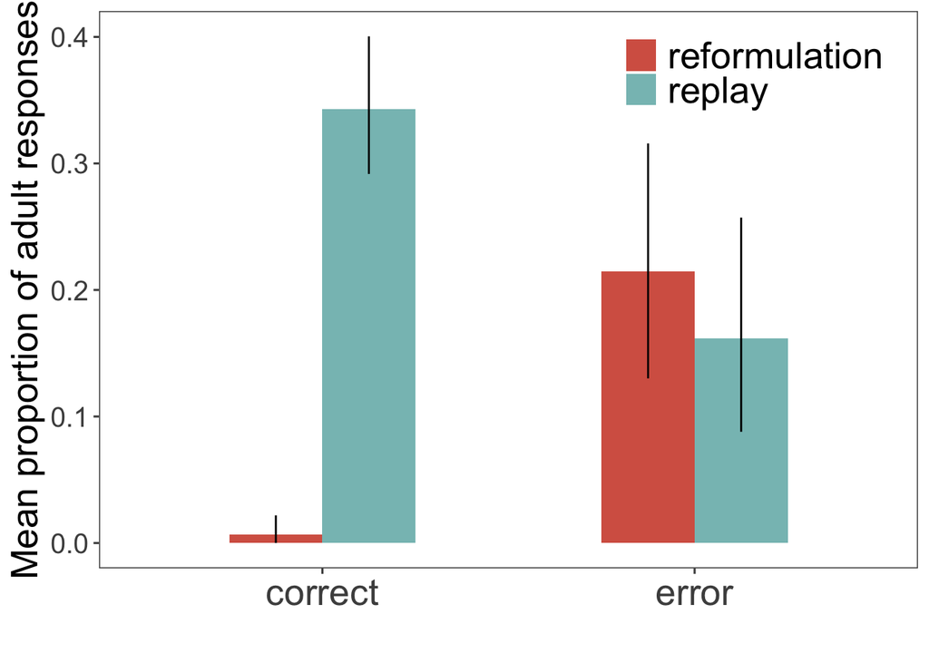

```r
ggplot(boot_responses_under_four, aes(x = plural_type, y = empirical_stat,
                           fill = response_type)) +
  geom_col(position = position_dodge(.5),
           width = .5) +
  geom_linerange(aes(ymin=ci_lower, ymax=ci_upper),
                 position=position_dodge(.5)) +
  labs(x = "Child Correctness", y= "Mean proportion of adult responses",
        title = ) +
  theme_few() +
  theme(legend.position = c(.8,.9), legend.title = element_blank(),
        axis.text.x = element_text(size = 20),
        axis.text.y = element_text(size = 15),
        axis.title = element_text(size = 20),
        legend.text = element_text(size = 20)) +
  xlab("") +
  guides(fill = guide_legend(title = "Response Type")) +
  scale_fill_manual(values = c("#D66252", "#87BFBF"))
```

### Information Gain Analyses:

```r
correct_dis <- up_to_four %>%
  ungroup() %>%
  summarise(correct = mean(plural_type == "correct"),
            error = mean(plural_type == "error"),
            total = n())

replay_dis <- up_to_four %>%
  group_by(replay) %>%
  summarise(correct = mean(plural_type == "correct"),
            error = mean(plural_type == "error"),
            total = n())

reform_dis <- up_to_four %>%
  mutate(reform = if_else(!is.na(reformulation), TRUE, FALSE)) %>%
  group_by(reform) %>%
  summarise(correct = mean(plural_type == "correct"),
            error = mean(plural_type == "error"),
            total = n())

replay_dis_true <- replay_dis %>%
  filter(replay == TRUE)

replay_dis_false <- replay_dis %>%
  filter(replay == FALSE)

reform_dis_true <- reform_dis %>%
  filter(reform == TRUE)

reform_dis_false <- reform_dis %>%
  filter(reform == FALSE)

entropy <- function (class0, class1) {
  return( -(class0 * log2(class0) + class1 * log2(class1)))
}

s_entropy <- entropy(correct_dis$correct, correct_dis$error)
s1_entropy <- entropy(replay_dis_true$correct, replay_dis_true$error)
s2_entropy <- entropy(replay_dis_false$correct, replay_dis_false$error)

sa_entropy <- (replay_dis_true$total/correct_dis$total * s1_entropy +
                       replay_dis_false$total/correct_dis$total * s2_entropy)

replay_gain <- s_entropy - sa_entropy

s1_reform_entropy <- entropy(reform_dis_true$correct, reform_dis_true$error)
s2_reform_entropy <- entropy(reform_dis_false$correct, reform_dis_false$error)

sa_reform_entropy <- (reform_dis_true$total/correct_dis$total * s1_reform_entropy +
                              reform_dis_false$total/correct_dis$total * s2_reform_entropy)

reform_gain <- s_entropy - sa_reform_entropy
```

Overall entropy of the sample was 0.407. Entropy(Accuracy, Reformulation) was 0.335

IG(Accuracy, Replay) and IG(A, Reformulation) was 0.013 and 0.072 bits respectively.

### Breakdown by word (4 and under)

```r
by_word_four <- up_to_four %>%
  mutate(reform.true = ifelse(is.na(reformulation), FALSE, TRUE),
         other.true = ifelse(reform.true | replay, FALSE, TRUE)) %>%
  filter(!is.na(gloss)) %>%
  group_by(plural_type, word, .drop = FALSE) %>%
  summarise(n.children = length(unique(target_child_id)), n.utterances = n(),
            replay = sum(replay, na.rm=TRUE),
            reformulation = sum(reform.true, na.rm=TRUE),
            other = sum(other.true, na.rm=TRUE)) %>%
  ungroup() %>%
  complete(plural_type, word, fill=list(n.children = 0, n.utterances = 0, replay = 0, reformulation = 0, other = 0))

by_word_four
```

```
## # A tibble: 34 × 7
##    plural_type word      n.children n.utterances replay reformulation other
##    <chr>       <chr>          <int>        <int>  <int>         <int> <int>
##  1 correct     child             51          223     71             2   150
##  2 correct     fireman           13           24      7             0    17
##  3 correct     fisherman          1            1      0             0     1
##  4 correct     foot              84          713    257             1   455
##  5 correct     goose             11           37     27             0    10
##  6 correct     half               3            4      1             0     3
##  7 correct     knife              8           20      1             0    19
##  8 correct     leaf              29          175     81             0    94
##  9 correct     mailman            1            1      1             0     0
## 10 correct     man               36          320    106             0   214
## # ℹ 24 more rows
```

### Child responses to reformulation table

```r
child_up_to_four <- child_responses %>%
  mutate(age_raw = target_child_age/12, age_years = floor(age_raw)) %>%
  filter(age_years < 5, !is.na(gloss)) %>%
  mutate(reform.true = ifelse(is.na(reformulation), FALSE, TRUE))

child_reform_four <- child_up_to_four %>%
  filter(!is.na(reformulation), speaker_role == "Target_Child", plural_type == "error") %>%
  group_by(plural_type) %>%
  summarise(repeated_error = (sum(repeated_plural, na.rm=TRUE)),
            repeated_reform = sum(repeated_reformulation, na.rm=TRUE))

child_reform_four
```

```
## # A tibble: 1 × 3
##   plural_type repeated_error repeated_reform
##   <chr>                <int>           <int>
## 1 error                    5               2
```

### Calculating bootstrapped child uptake of reformulations and repetitions

```r
booted_repeated_reformulations <- child_up_to_four %>%
  filter(!is.na(reformulation), speaker_role == "Target_Child") %>%
  pivot_longer(c(repeated_plural, repeated_reformulation),
               names_to = "response_type",
               values_to = "rate") %>%
  group_by(plural_type, response_type, target_child_id) %>%
  summarise(rate = mean(rate)) %>%
  tidyboot_mean(rate) %>%
  mutate(response_type = factor(response_type,
                                levels=c("repeated_reformulation",
                                         "repeated_plural"),
                          labels = c("take up reformulation", "repeat error")))
booted_replay_replies <- child_up_to_four %>%
  filter(parent_replay == TRUE, speaker_role == "Target_Child") %>%
  pivot_longer(c(repeated_plural, form_change),
               names_to = "response_type",
               values_to = "rate") %>%
  group_by(plural_type, response_type, target_child_id) %>%
  summarise(rate = mean(rate)) %>%
  tidyboot_mean(rate, na.rm = TRUE) %>%
  mutate(response_type = factor(response_type,
                                levels=c("form_change", "repeated_plural"),
                          labels = c("Change to New Form", "Use Original Form")))
```

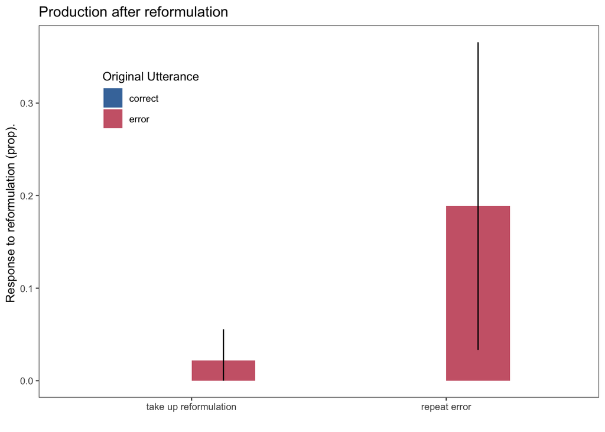

```r
ggplot(booted_repeated_reformulations, aes(x=response_type, y=empirical_stat, fill= plural_type)) +
  geom_col(position = position_dodge(.5),
           width = .5) +
  geom_linerange(aes(ymin=ci_lower, ymax=ci_upper),
                 position=position_dodge(.5)) +
  labs(y= "Response to reformulation (prop). ", title = "Production after reformulation") +
  theme_few(base_size = 10) +
  theme(legend.position = c(.2,.8)) +
  xlab("") +
  scale_fill_ptol() +
  guides(fill = guide_legend(title = "Original Utterance"))
```

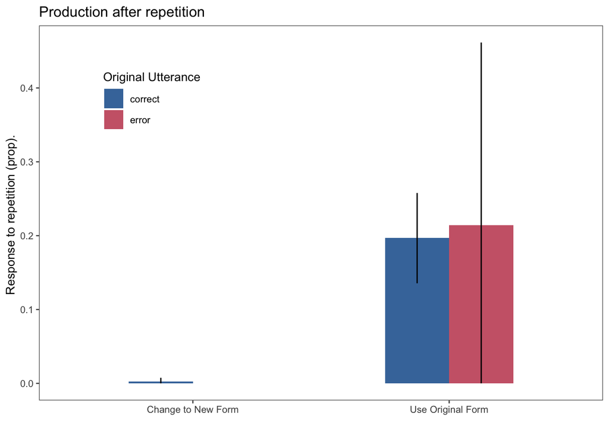

```r
ggplot(booted_replay_replies, aes(x=response_type, y=empirical_stat,
                       fill= plural_type)) +
  geom_col(position = position_dodge(.5),
           width = .5) +
  geom_linerange(aes(ymin=ci_lower, ymax=ci_upper),
                 position=position_dodge(.5)) +
  labs(y= "Response to repetition (prop). ", title = "Production after repetition") +
  theme_few(base_size = 10) +
  theme(legend.position = c(.2,.8)) +
  xlab("") +
  scale_fill_ptol() +
  guides(fill = guide_legend(title = "Original Utterance"))
```

Dividing words based on plural or singular frequency

```r
frequencies <- read_csv(here("Corpus/Frequencies.csv")) %>%
  mutate(Difference = `Singular Frequency` - `Plural Frequency`) %>%
  mutate(More_Common = ifelse(Difference < 0, "plural", "singular"))
freq_word <- left_join(by_word_four, frequencies, by = c("word" = "Word"))

plural_common <- freq_word %>% filter(More_Common == "plural")
```

# Analyses for children of all ages:

### Calculating the average reformulation and replay rates dependent on whether or not the child used a correct or incorrect plural form.

```r
boot_responses <- parent_responses %>%
  group_by(target_child_id, plural_type) %>%
  summarise(replay = mean(replay == TRUE),
            reformulation = mean(!is.na(reformulation))) %>%
  pivot_longer(cols = replay:reformulation,  names_to = "response_type",
               values_to = "rate") %>%
  ungroup() %>%
  group_by(plural_type, response_type) %>%
  tidyboot_mean(rate, na.rm = TRUE)
```

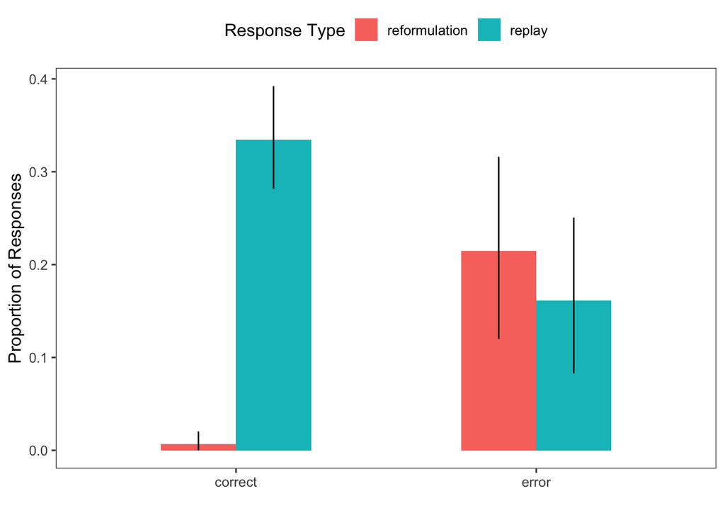

```r
ggplot(boot_responses, aes(x = plural_type, y = empirical_stat,
                           fill = response_type)) +
  geom_col(position = position_dodge(.5),
           width = .5) +
  geom_linerange(aes(ymin=ci_lower, ymax=ci_upper),
                 position=position_dodge(.5)) +
  ylab("Proportion of Responses") +
  theme_few() +
  theme(legend.position = "top") +
  xlab("") +
  guides(fill = guide_legend(title = "Response Type"))
```

### Following table organizes response counts by word

```r
responses_by_word <- parent_responses %>%
  mutate(reform.true = ifelse(is.na(reformulation), FALSE, TRUE),
         other.true = ifelse(reform.true | replay, FALSE, TRUE)) %>%
  group_by(plural_type, word) %>%
  summarise(n.children = length(unique(target_child_id)), n.utterances = n(),
            replay = sum(replay, na.rm=TRUE),
            reformulation = sum(reform.true, na.rm=TRUE),
            other = sum(other.true, na.rm=TRUE))
```

### Dataframe of child responses to parent reformulations

### First organized by word:

```r
child_reform_word <- child_responses %>%
  filter(!is.na(reformulation), speaker_role == "Target_Child", plural_type == "error") %>%
  group_by(plural_type, word) %>%
  summarise(n.utterances = n(), repeated_error = (sum(repeated_plural, na.rm=TRUE)),
            repeated_reform = sum(repeated_reformulation, na.rm=TRUE))
```

```r
child_replays_word <- child_responses %>%
  filter(parent_replay == TRUE, speaker_role == "Target_Child") %>%
  group_by(plural_type, word) %>%
  summarise(n.utterances = n(), repeated_plural = sum(repeated_plural, na.rm=TRUE),
            form_change = sum(form_change, na.rm=TRUE))
```

### Then organized by age:

```r
child_reform_age <- child_responses %>%
  filter(!is.na(reformulation), speaker_role == "Target_Child") %>%
  mutate(age_years = factor(floor(target_child_age/12), levels = c("0", "1", "2", "3", "4", "5", "6", "7", "8", "9","10")), other.true = ifelse(repeated_plural | repeated_reformulation, FALSE, TRUE)) %>%
  filter(!is.na(gloss)) %>%
  group_by(plural_type, age_years) %>%
  summarise(n.children = length(unique(target_child_id)), n.utterances = n(),
            repeated_error = (sum(repeated_plural, na.rm=TRUE)),
            repeated_reform = (sum(repeated_reformulation, na.rm=TRUE)),
            other = (sum(other.true, na.rm=TRUE))) %>%
  ungroup() %>%
  complete(plural_type, age_years, fill=list(n.children = 0, n.utterances = 0, repeated_reform = 0, repeated_error = 0, other = 0))

child_replay_age <- child_responses %>%
  filter(parent_replay == TRUE, speaker_role == "Target_Child") %>%
  mutate(age_years = factor(floor(target_child_age/12), levels = c("0", "1", "2", "3", "4", "5", "6", "7", "8", "9","10")), other.true = ifelse(repeated_plural | form_change, FALSE, TRUE)) %>%
  filter(!is.na(gloss)) %>%
  group_by(plural_type, age_years) %>%
  summarise(n.children = length(unique(target_child_id)), n.utterances = n(),
            repeated_plural = sum(repeated_plural, na.rm=TRUE),
            form_change = sum(form_change, na.rm=TRUE),
            other = sum(other.true, na.rm=TRUE)) %>%
  ungroup() %>%
  complete(plural_type, age_years, fill=list(n.children = 0, n.utterances = 0, repeated_plural = 0, form_change = 0, other = 0))
```